# Shopping Behavior and Product Rating Analysis

Martin Okwumuo

2026-01-10

#Introduction

This analysis explores customer behavior and product performance using a retail dataset. The dataset was gotten from Kaggle at “https://www.kaggle.com/datasets/nalisha/shopping-behaviour-and-product-ranking-dateset”. The goal is to draw insight from the dataset on which age bracket makes the most purchases, the season with the highest sales volume, the location with highest sales volume and general customer behavioral pattern to help improve sales and customer rating.

# Data Preprocessing

## Loading the Required Libraries

```r
library(tidyverse)
library(janitor)
```

```r
library(lubridate)
library(ggplot2)
library(dplyr)
```

## Downloading the data

```r
# Dataset identifier
dataset <- "nalisha/shopping-behaviour-and-product-ranking-dateset"

# Create data directory if it doesn't exist
if (!dir.exists("../data")) {
  dir.create("../data")
}

# Download only if file does not already exist
if (!file.exists("../data/shopping_behavior_updated.csv")) {
  system(
    paste(
      "kaggle datasets download",
      dataset,
      "-p ../data --unzip"
    )
  )
}
```

```
## [1] 0
```

```r
list.files("../data")
```

```
## [1] "shopping_behavior_updated (1).csv"
```

## 3. Load and Inspect the Data

### Load dataset

```r
customer_data <- read_csv("../data/shopping_behavior_updated (1).csv")
head(customer_data)
```

```
## # A tibble: 6 x 16
##   `Customer ID`   Age Gender `Item Purchased` Category `Purchase Amount (USD)`
##           <dbl> <dbl> <chr>  <chr>            <chr>                      <dbl>
## 1             1    55 Male   Blouse           Clothing                      53
## 2             2    19 Male   Sweater          Clothing                      64
## 3             3    50 Male   Jeans            Clothing                      73
## 4             4    21 Male   Sandals          Footwear                      90
## 5             5    45 Male   Blouse           Clothing                      49
## 6             6    46 Male   Sneakers         Footwear                      20
## # i 10 more variables: Location <chr>, Size <chr>, Color <chr>, Season <chr>,
## #   `Review Rating` <dbl>, `Subscription Status` <chr>,
## #   `Discount Applied` <chr>, `Previous Purchases` <dbl>,
## #   `Payment Method` <chr>, `Frequency of Purchases` <chr>
```

## Clean column names

```r
data <- clean_names(customer_data)
```

## Preview data

```r
head(data)
```

```
## # A tibble: 6 x 16
##   customer_id   age gender item_purchased category purchase_amount_usd location
##         <dbl> <dbl> <chr>  <chr>          <chr>                  <dbl> <chr>
## 1           1    55 Male   Blouse         Clothing                  53 Kentucky
## 2           2    19 Male   Sweater        Clothing                  64 Maine
## 3           3    50 Male   Jeans          Clothing                  73 Massachu~
## 4           4    21 Male   Sandals        Footwear                  90 Rhode Is~
## 5           5    45 Male   Blouse         Clothing                  49 Oregon
## 6           6    46 Male   Sneakers       Footwear                  20 Wyoming
## # i 9 more variables: size <chr>, color <chr>, season <chr>,
## #   review_rating <dbl>, subscription_status <chr>, discount_applied <chr>,
## #   previous_purchases <dbl>, payment_method <chr>,
## #   frequency_of_purchases <chr>
```

```r
glimpse(data)
```

```
## Rows: 3,900
## Columns: 16
## $ customer_id            <dbl> 1, 2, 3, 4, 5, 6, 7, 8, 9, 10, 11, 12, 13, 14, ~
## $ age                    <dbl> 55, 19, 50, 21, 45, 46, 63, 27, 26, 57, 53, 30,~
## $ gender                 <chr> "Male", "Male", "Male", "Male", "Male", "Male",~
## $ item_purchased         <chr> "Blouse", "Sweater", "Jeans", "Sandals", "Blous~
## $ category               <chr> "Clothing", "Clothing", "Clothing", "Footwear",~
## $ purchase_amount_usd    <dbl> 53, 64, 73, 90, 49, 20, 85, 34, 97, 31, 34, 68,~
## $ location               <chr> "Kentucky", "Maine", "Massachusetts", "Rhode Is~
## $ size                   <chr> "L", "L", "S", "M", "M", "M", "M", "L", "L", "M~
## $ color                  <chr> "Gray", "Maroon", "Maroon", "Maroon", "Turquois~
## $ season                 <chr> "Winter", "Winter", "Spring", "Spring", "Spring~
## $ review_rating          <dbl> 3.1, 3.1, 3.1, 3.5, 2.7, 2.9, 3.2, 3.2, 2.6, 4.~
## $ subscription_status    <chr> "Yes", "Yes", "Yes", "Yes", "Yes", "Yes", "Yes"~
## $ discount_applied       <chr> "Yes", "Yes", "Yes", "Yes", "Yes", "Yes", "Yes"~
## $ previous_purchases     <dbl> 14, 2, 23, 49, 31, 14, 49, 19, 8, 4, 26, 10, 37~
## $ payment_method         <chr> "Venmo", "Cash", "Credit Card", "PayPal", "PayP~
## $ frequency_of_purchases <chr> "Fortnightly", "Fortnightly", "Weekly", "Weekly~
```

# Structure and summary

```r
str(data)
```

```
## spc_tbl_ [3,900 x 16] (S3: spec_tbl_df/tbl_df/tbl/data.frame)
##  $ customer_id           : num [1:3900] 1 2 3 4 5 6 7 8 9 10 ...
##  $ age                   : num [1:3900] 55 19 50 21 45 46 63 27 26 57 ...
##  $ gender                : chr [1:3900] "Male" "Male" "Male" "Male" ...
##  $ item_purchased        : chr [1:3900] "Blouse" "Sweater" "Jeans" "Sandals" ...
##  $ category              : chr [1:3900] "Clothing" "Clothing" "Clothing" "Footwear" ...
##  $ purchase_amount_usd   : num [1:3900] 53 64 73 90 49 20 85 34 97 31 ...
##  $ location              : chr [1:3900] "Kentucky" "Maine" "Massachusetts" "Rhode Island" ...
##  $ size                  : chr [1:3900] "L" "L" "S" "M" ...
##  $ color                 : chr [1:3900] "Gray" "Maroon" "Maroon" "Maroon" ...
##  $ season                : chr [1:3900] "Winter" "Winter" "Spring" "Spring" ...
##  $ review_rating         : num [1:3900] 3.1 3.1 3.1 3.5 2.7 2.9 3.2 3.2 2.6 4.8 ...
##  $ subscription_status   : chr [1:3900] "Yes" "Yes" "Yes" "Yes" ...
##  $ discount_applied      : chr [1:3900] "Yes" "Yes" "Yes" "Yes" ...
##  $ previous_purchases    : num [1:3900] 14 2 23 49 31 14 49 19 8 4 ...
##  $ payment_method        : chr [1:3900] "Venmo" "Cash" "Credit Card" "PayPal" ...
##  $ frequency_of_purchases: chr [1:3900] "Fortnightly" "Fortnightly" "Weekly" "Weekly" ...
##  - attr(*, "spec")=
##   .. cols(
##   ..   `Customer ID` = col_double(),
##   ..   Age = col_double(),
##   ..   Gender = col_character(),
##   ..   `Item Purchased` = col_character(),
##   ..   Category = col_character(),
##   ..   `Purchase Amount (USD)` = col_double(),
##   ..   Location = col_character(),
##   ..   Size = col_character(),
##   ..   Color = col_character(),
##   ..   Season = col_character(),
##   ..   `Review Rating` = col_double(),
##   ..   `Subscription Status` = col_character(),
##   ..   `Discount Applied` = col_character(),
##   ..   `Previous Purchases` = col_double(),
##   ..   `Payment Method` = col_character(),
##   ..   `Frequency of Purchases` = col_character()
##   .. )
##  - attr(*, "problems")=<externalptr>
```

```r
summary(data)
```

```
##   customer_id          age           gender          item_purchased
##  Min.   :   1.0   Min.   :18.00   Length:3900        Length:3900
##  1st Qu.: 975.8   1st Qu.:31.00   Class :character   Class :character
##  Median :1950.5   Median :44.00   Mode  :character   Mode  :character
##  Mean   :1950.5   Mean   :44.07
##  3rd Qu.:2925.2   3rd Qu.:57.00
##  Max.   :3900.0   Max.   :70.00
##    category         purchase_amount_usd   location             size
##  Length:3900        Min.   : 20.00      Length:3900        Length:3900
##  Class :character   1st Qu.: 39.00      Class :character   Class :character
##  Mode  :character   Median : 60.00      Mode  :character   Mode  :character
##                     Mean   : 59.76
##                     3rd Qu.: 81.00
##                     Max.   :100.00
##     color              season          review_rating  subscription_status
##  Length:3900        Length:3900        Min.   :2.50   Length:3900
##  Class :character   Class :character   1st Qu.:3.10   Class :character
##  Mode  :character   Mode  :character   Median :3.70   Mode  :character
##                                        Mean   :3.75
##                                        3rd Qu.:4.40
##                                        Max.   :5.00
##  discount_applied   previous_purchases payment_method
##  Length:3900        Min.   : 1.00      Length:3900
##  Class :character   1st Qu.:13.00      Class :character
##  Mode  :character   Median :25.00      Mode  :character
##                     Mean   :25.35
##                     3rd Qu.:38.00
##                     Max.   :50.00
##  frequency_of_purchases
##  Length:3900
##  Class :character
##  Mode  :character
##
##
##
```

# Data Preparation

## Checking for missing data

```r
sum(is.na(data))
```

```
## [1] 0
```

## Checking for duplicate data

```r
sum(duplicated(data))
```

```
## [1] 0
```

## Create Age Brackets

```r
data <- data %>%
mutate(age_group = case_when(
age < 18 ~ "Under 18",
age >= 18 & age <= 25 ~ "18–25",
age >= 26 & age <= 35 ~ "26–35",
age >= 36 & age <= 45 ~ "36–45",
age >= 46 & age <= 60 ~ "46–60",
TRUE ~ "60+"
))
```

## Age Bracket with the Most Purchases

```r
age_sales <- data %>%
group_by(age_group) %>%
summarise(
total_purchases = n(),
total_sales = sum(purchase_amount_usd, na.rm = TRUE)
) %>%
arrange(desc(total_purchases))
age_sales
```

```
## # A tibble: 5 x 3
##   age_group total_purchases total_sales
##   <chr>               <int>       <dbl>
## 1 46–60                1135       67711
## 2 26–35                 742       44342
## 3 36–45                 729       43234
## 4 60+                   723       43164
## 5 18–25                 571       34630
```

# Visualization

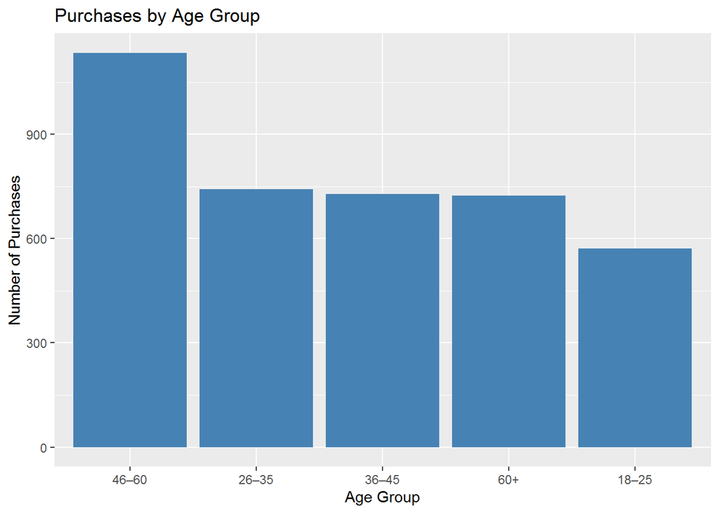

```r
age_sales %>%
ggplot(aes(x = reorder(age_group, -total_purchases), y = total_purchases)) +
geom_col(fill = "steelblue") +
labs(title = "Purchases by Age Group",
x = "Age Group",
y = "Number of Purchases")
```

## Season with the Highest Sales Volume

```r
season_sales <- data %>%
group_by(season) %>%
summarise(
total_purchases = n(),
total_sales = sum(purchase_amount_usd, na.rm = TRUE)
) %>%
arrange(desc(total_sales))

season_sales
```

```
## # A tibble: 4 x 3
##   season total_purchases total_sales
##   <chr>            <int>       <dbl>
## 1 Fall               975       60018
## 2 Spring             999       58679
## 3 Winter             971       58607
## 4 Summer             955       55777
```

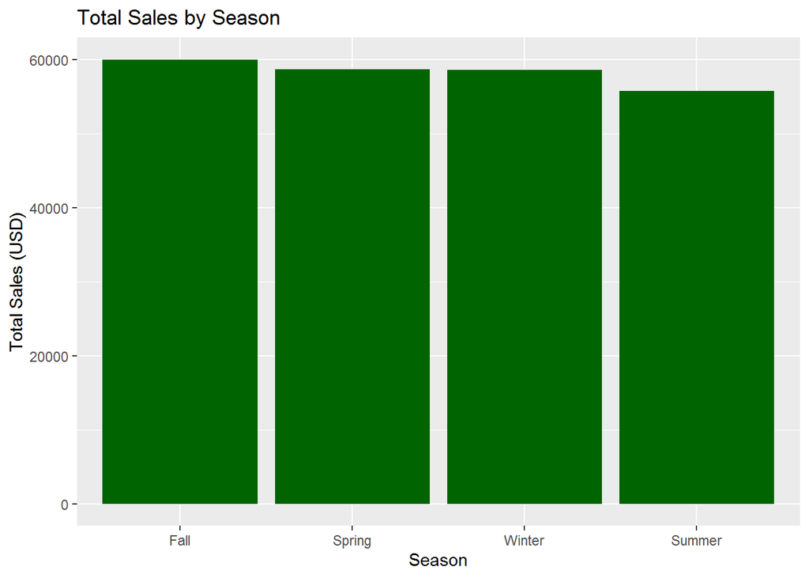

```r
season_sales %>%
ggplot(aes(x = reorder(season, -total_sales), y = total_sales)) +
geom_col(fill = "darkgreen") +
labs(title = "Total Sales by Season",
x = "Season",
y = "Total Sales (USD)")
```

## Location with the Highest Sales Volume

```r
location_sales <- data %>%
group_by(location) %>%
summarise(
total_purchases = n(),
total_sales = sum(purchase_amount_usd, na.rm = TRUE)
) %>%
arrange(desc(total_sales))
location_sales
```

```
## # A tibble: 50 x 3
##    location      total_purchases total_sales
##    <chr>                   <int>       <dbl>
##  1 Montana                    96        5784
##  2 Illinois                   92        5617
##  3 California                 95        5605
##  4 Idaho                      93        5587
##  5 Nevada                     87        5514
##  6 Alabama                    89        5261
##  7 New York                   87        5257
##  8 North Dakota               83        5220
##  9 West Virginia              81        5174
## 10 Nebraska                   87        5172
## # i 40 more rows
```

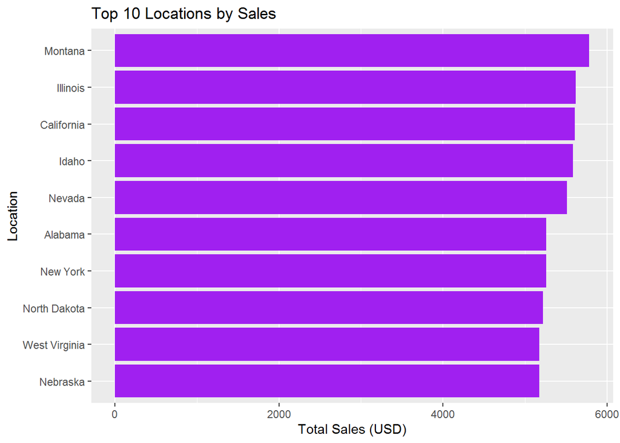

```r
location_sales %>%
top_n(10, total_sales) %>%
ggplot(aes(x = reorder(location, total_sales), y = total_sales)) +
geom_col(fill = "purple") +
coord_flip() +
labs(title = "Top 10 Locations by Sales",
x = "Location",
y = "Total Sales (USD)")
```

## Top items purchased in a particular season

```r
top_category_per_season <- data %>%
  group_by(season, item_purchased) %>%
  summarise(
    total_sales = sum(purchase_amount_usd, na.rm = TRUE),
    .groups = "drop"
  ) %>%
  group_by(season) %>%
  slice_max(total_sales, n = 1)
top_category_per_season
```

```
## # A tibble: 4 x 3
## # Groups:   season [4]
##   season item_purchased total_sales
##   <chr>  <chr>                <dbl>
## 1 Fall   Hat                   3224
## 2 Spring Sweater               3145
## 3 Summer Jewelry               3006
## 4 Winter Shirt                 3102
```

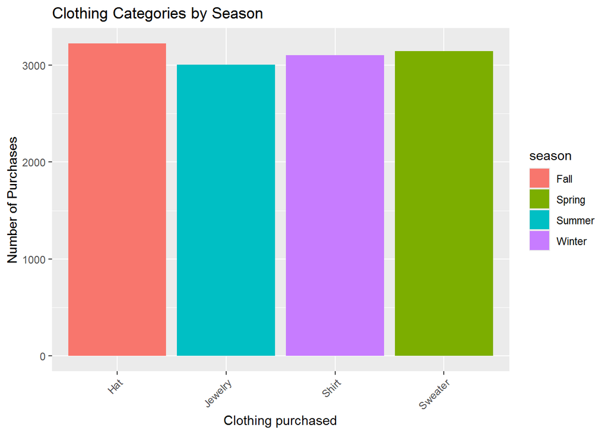

```r
top_category_per_season %>%
  ggplot(aes(x = item_purchased, y = total_sales, fill = season)) +
  geom_col(position = "dodge") +
  labs(
    title = "Clothing Categories by Season",
    x = "Clothing purchased",
    y = "Number of Purchases"
  ) +
  theme(axis.text.x = element_text(angle = 45, hjust = 1))
```